# Warmup 4: Financial Math Formulas

Felicia Liu

4/3/2021

# 1) Future Value (with compound interest)

$$FV=P(1+\frac{r}{k})^{nk}$$

- FV = future value (amount accumulated)
- P = principal (how much you start with)
- r = annual interest rate or annual rate of return
- n = number of years
- k = number of compounding periods per year

1.1) Function `future_value()`

```r
#' @title future value with compound interest
#' @description determine how much money you'll earn when you deposit a lump sum over time; without touching initial amount and without making additional contributions
#' @param P principal or how much you start with (numeric)
#' @param r annual interest rate or annual rate of return (numeric)
#' @param n number of years (numeric)
#' @param k number of compounding periods per year (numeric)
#' @return future value (amount accumulated)

future_value <- function(P = 0, r = 0, n = 0, k = 0) {
  fv <- P*(1+r/k)**(n*k)
  return(fv)
}
```

1.2) Use `future_value()` to answer the following questions

1. Paul deposits $1,000 in a Certificate of Deposit for 2 years at 2% per year compounded annually. What will be the value of the money at the end of 2 years?

```r
future_value(1000, 0.02, 2, 1)
```

```
## [1] 1040.4
```

Paul will have $1040.40 at the end of 2 years.

2. Let’s suppose that Paul deposits $1,000 in a Certificate of Deposit for 2 years at 2% per year, but this time it is compounded semi-annually. What will be the value of the money at the end of 2 years?

```r
future_value(1000, 0.02, 2, 2)
```

```
## [1] 1040.604
```

Paul will have $1040.60 at the end of 2 years.

3. When Amalie was born in 2000, her paternal grandparents decided to open a custodial account for her, investing $10,000 in a highly diversified U.S. stock market index fund. After 20 years, what would be the (expected) balance in Amalie’s account if this type of index fund has had an average annual rate of return of 9%?

```r
future_value(10000, 0.09, 20, 1)
```

```
## [1] 56044.11
```

After 20 years, the expected balance in Amalie’s account would be $56,044.11.

4. Suppose that Amalie’s maternal grandparents also decided to invest $10,000 in a highly diversified U.S. stock market index fund but they did it by setting up a trust in which Amalie could only have access to the assets when she is 30 years old. What would be the future value that Amalie is expecting to receive in her 30th birthday, if the index fund has the same average annual rate of return of 9%?

```r
future_value(10000, 0.09, 30, 1)
```

```
## [1] 132676.8
```

Amalie would be expecting to receive $132,676.80 on her 30th birthday.

5. This follows part (c). It would be nice to graph a timeline of the yearly balances inAmalie’s account. To do this, first generate a numeric sequence vector from 1 to 20 (i.e.1, 2, 3, … , 20) and pass this vector as the “number of years” argument in your function future_value(). In theory, future_value() should be vectorized and you should be able to obtain the balances at the end of every year with a single call to future_value(). In other words, there’s no need to use any type of loops.

```r
library(ggplot2)

vector_of_years <- c(1:20)
vector_of_balances <- future_value(10000, 0.09, vector_of_years, 1)

yearly_balances <- data.frame(x = vector_of_years, y = vector_of_balances)
colnames(yearly_balances) <- c("Years", "Balances")
yearly_balances
```

```
##    Years Balances
## 1      1 10900.00
## 2      2 11881.00
## 3      3 12950.29
## 4      4 14115.82
## 5      5 15386.24
## 6      6 16771.00
## 7      7 18280.39
## 8      8 19925.63
## 9      9 21718.93
## 10    10 23673.64
## 11    11 25804.26
## 12    12 28126.65
## 13    13 30658.05
## 14    14 33417.27
## 15    15 36424.82
## 16    16 39703.06
## 17    17 43276.33
## 18    18 47171.20
## 19    19 51416.61
## 20    20 56044.11
```

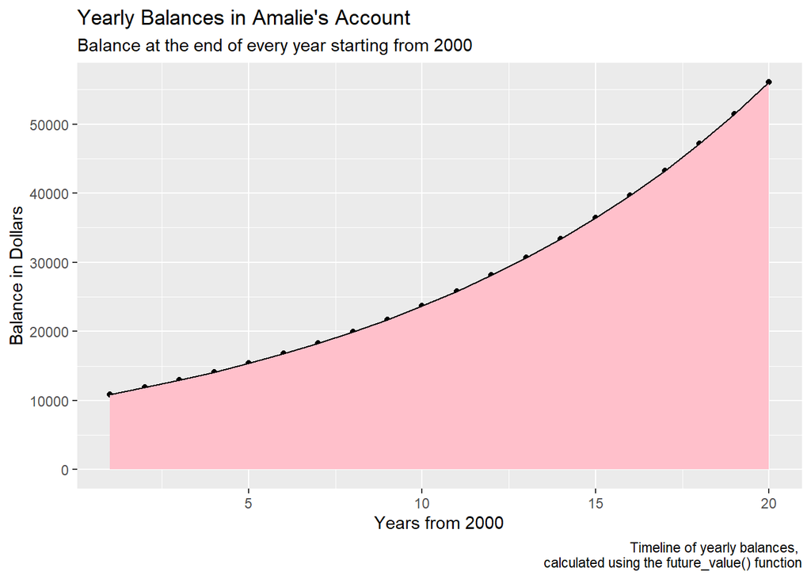

```r
ggplot(yearly_balances, aes(x = Years, y = Balances)) +
  geom_line() + geom_point() +
  geom_area(color = "black", fill = "pink") +
  scale_y_continuous(breaks = c(0, 10000, 20000, 30000, 40000,
                                50000, 60000)) +
  labs(title = "Yearly Balances in Amalie's Account",
       subtitle = "Balance at the end of every year starting from 2000",
       x = "Years from 2000",
       y = "Balance in Dollars",
       caption = "Timeline of yearly balances,
       calculated using the future_value() function")
```

# 2) Future Value of Annuity

ordinary annuity:
$$FV=PMT \times \frac{(1+\frac{r}{k})^{nk}-1}{r/k}$$

annuity due:
$$FV=PMT \times \frac{(1+\frac{r}{k})^{nk}-1}{r/k} \times (1+\frac{r}{k})$$

- FV = future value (amount accumulated)
- PMT = periodic contribution made in each period
- r = annual interest rate or annual rate of return
- n = number of years
- k = number of compounding periods per year

2.1) Function `annuity()`

```r
#' @title future value of an annuity
#' @description measures how much a series of fixed payments would be worth at a specific date in the future when paired with particular interest rate
#' @param PMT periodic contribution made in each period (numeric)
#' @param r annual interest rate or annual rate of return (numeric)
#' @param n number of years (numeric)
#' @param k number of compounding periods per year (numeric)
#' @return future value (amount accumulated)

annuity <- function(PMT = 0, r = 0, n = 0, k = 0, due = FALSE) {
  if (due == FALSE) {
    annuity_fv <- PMT*((1+r/k)**(n*k)-1)/(r/k)
    return(annuity_fv)
  } else {
    annuity_fv <- PMT*((1+r/k)**(n*k)-1)/(r/k)*(1+r/k)
    return(annuity_fv)
  }
}
```

2.2) Use `annuity()` to answer the following questions

1. Mr. X deposits an amount of $1200 at the end of each year for the next ten years for his son’s education. How much money will Mr. X have at the end of ten years if the annual rate of return is 6%?

```r
annuity(1200, 0.06, 10, 1, due = FALSE)
```

```
## [1] 15816.95
```

Mr. X will have $15,816.95 for his son’s education at the end of 10 years.

2. Mrs. Y deposits an amount of $100 at the end of each month for the next ten years for her daughter’s education. How much money will Mrs. Y have at the end of ten years if the annual rate of return is 6%?

```r
annuity(100, 0.06, 10, 12, due = FALSE)
```

```
## [1] 16387.93
```

Mrs. Y will have $16,387.93 for her daughter’s education at the end of 10 years.

3. Mr. and Mrs. Z deposit an amount of $100 at the beginning of each month for the next ten years for traveling purposes. How much money will they have at the end of ten years if the annual rate of return is 6%?

```r
annuity(100, 0.06, 10, 12, due = TRUE)
```

```
## [1] 16469.87
```

Mr. and Mrs. Z will have $16,469.87 for traveling purposes at the end of 10 years.

# 3) Combo: Future Value and Annuity

Future value of investment if the periodic contribution is made at the end of each period:

$$FV=P(1+\frac{r}{k})^{nk}+PMT \times \frac{(1+\frac{r}{k})^{nk}-1}{r/k}$$

Future value of the investment if the periodic contribution is made at the beginning of each period:

$$FV=P(1+\frac{r}{k})^{nk}+PMT \times \frac{(1+\frac{r}{k})^{nk}-1}{r/k} \times (1+\frac{r}{k})$$

- FV = future value of investment
- P = principal (how much you start with)
- PMT = periodic contribution made in each period
- r = annual interest rate or annual rate of return
- n = number of years
- k = number of periods (k = 12 monthly contributions, k = 1 annual contributions)

If r = 0, then:

$$FV=P+PMT \times nk$$

3.1) Use `future_value()` and `annuity()` to answer the following questions

1. Assume an annual rate of return of 7.55% for a stock index fund. What is the future value of initially investing $1000, and then making contributions of $720 at the end of each year during 20 years?

```r
future_value(1000, 0.0755, 20, 1) + annuity(720, 0.0755, 20, 1, due = FALSE)
```

```
## [1] 35638.93
```

The future value will be $35,638.93.

2. Assume an annual rate of return of 7.55% for a stock index fund. What is the future value of initially investing $1000, and then making contributions of $60 at the end of each month during 20 years?

```r
future_value(1000, 0.0755, 20, 12) + annuity(60, 0.0755, 20, 12, due = FALSE)
```

```
## [1] 37934.05
```

The future value will be $37,934.05.

3. Assume an annual rate of return of 7.55% for a stock index fund. What is the future value of initially investing $1000, and then making contributions of $60 at the beginning of each month during 20 years?

```r
future_value(1000, 0.0755, 20, 12) + annuity(60, 0.0755, 20, 12, due = TRUE)
```

```
## [1] 38144.37
```

The future value will be $38,144.37.

# 4) Monthly Payment of Amortization Formula

$$PMT = P \times \frac{\frac{r}{k}(1+\frac{r}{k})^{nk}}{(1+\frac{r}{k})^{nk}-1}$$

- P = principal (lended amount)
- PMT = periodic payment (typically monthly = EMI)
- r = interest rate
- n = number of years
- k = number of periodic payments (typically 12: monthly)

4.1) Function `amortization()`

```r
#' @title monthly payment of amortization
#' @description calculate the fixed monthly payment of a loan
#' @param P principal (lended amount) (numeric)
#' @param r interest rate (numeric)
#' @param n number of years (numeric)
#' @param k number of periodic payments (numeric)
#' @return amount paid (typically monthly when k=12) of a loan amortization

amortization <- function(P = 0, r = 0, n = 0, k = 0) {
  periodic_payment <- P*((r/k)*(1+r/k)**(n*k))/(((1+r/k)**(n*k))-1)
  return(periodic_payment)
}
```

4.2) Use `amortization()` to answer the following questions

1. A salaried person took a home loan from a bank of $100,000 at the rate of interest of 5% for a period of 20 years. Calculate the monthly payments to the bank.

```r
amortization(100000, 0.05, 20, 12)
```

```
## [1] 659.9557
```

The monthly payment to the bank should be approximately $659.96.

2. Consider the previous part (a); but now assume a variable interest rate that could be either 4%, 5% or 6%. Pass a vector of interest rates to your function amortization()and obtain the three different monthly payments.

```r
interest_rates <- c(0.04, 0.05, 0.06)

three_monthly_payments <- amortization(100000, interest_rates, 20, 12)
three_monthly_payments
```

```
## [1] 605.9803 659.9557 716.4311
```

The three different monthly payments are: $605.98, $659.96, $716.43.

# 5) Loan Amortization Calculator

5.1) Schedule payment table

5.2) Formulas for schedule payment table

Periodic Payment:

$$pmt = P \times \frac{\frac{r}{k}(1+\frac{r}{k})^{nk}}{(1+\frac{r}{k})^{nk}-1}$$

Principal Balance:

$$balance_{m}= P \times (1+\frac{r}{k})^{m} - pmt \times \frac{(1+\frac{r}{k})^m-1}{r/k}$$

- m = specific period of time

Interest Paid:

$$interest_{m} = balance_{m} \times \frac{r}{k}$$

- m = specific period of time

Principal Paid:

$$principal_{m} = pmt - interest_{m}$$

- m = specific period of time

5.3) Function `loan_calculator()`

```r
#' @title loan calculator that returns an amortization table
#' @description takes in the loan amount, number of years, interest rate, and number of periods per year to return an amortization table
#' @param P principal (loan amount) (numeric)
#' @param r interest rate (numeric)
#' @param n number of years (numeric)
#' @param k number of periods per year (numeric)
#' @return amortization table in the form of a data frame (7 columns)

loan_calculator <- function(P = 0, r = 0, n = 0, k = 0) {
  m <- c(0:(n*k-1))
  pmt = amortization(P, r, n, k)
  remaining_balance <- P*(1+r/k)**m - pmt*(((1+r/k)**m)-1)/(r/k)
  paid_interest <- remaining_balance*(r/k)
  paid_cum_interest <- cumsum(paid_interest)
  paid_principal <- pmt - paid_interest
  paid_cum_principal <- cumsum(paid_principal)
  amortization_table <- data.frame(m, remaining_balance, pmt, paid_interest,
                                   paid_cum_interest, paid_principal,
                                   paid_cum_principal)
  colnames(amortization_table) = c("term", "balance",
                                 "payment", "paid_interest",
                                 "paid_cum_interest", "paid_principal",
                                 "paid_cum_principal")
  return(amortization_table)
}
```

5.4) Loan payment schedule and graph

1. Use your loan_calculator() function to get an amortization table of monthly payments for a car loan of $20,000, with an annual interest rate of 3.5%, for 5 years.

```r
amortization_table <- loan_calculator(20000, 0.035, 5, 12)
amortization_table
```

```
##    term    balance  payment paid_interest paid_cum_interest paid_principal
## 1     0 20000.0000 363.8349     58.333333          58.33333       305.5016
## 2     1 19694.4984 363.8349     57.442287         115.77562       306.3926
## 3     2 19388.1058 363.8349     56.548642         172.32426       307.2863
## 4     3 19080.8196 363.8349     55.652390         227.97665       308.1825
## 5     4 18772.6371 363.8349     54.753525         282.73018       309.0814
## 6     5 18463.5557 363.8349     53.852037         336.58221       309.9829
## 7     6 18153.5728 363.8349     52.947921         389.53014       310.8870
## 8     7 17842.6858 363.8349     52.041167         441.57130       311.7937
## 9     8 17530.8921 363.8349     51.131769         492.70307       312.7031
## 10    9 17218.1890 363.8349     50.219718         542.92279       313.6152
## 11   10 16904.5738 363.8349     49.305007         592.22780       314.5299
## 12   11 16590.0439 363.8349     48.387628         640.61542       315.4473
## 13   12 16274.5966 363.8349     47.467574         688.08300       316.3673
## 14   13 15958.2293 363.8349     46.544835         734.62783       317.2901
```

[output cut: 107 more lines]

```r
library("dplyr")
library("reshape2")
```

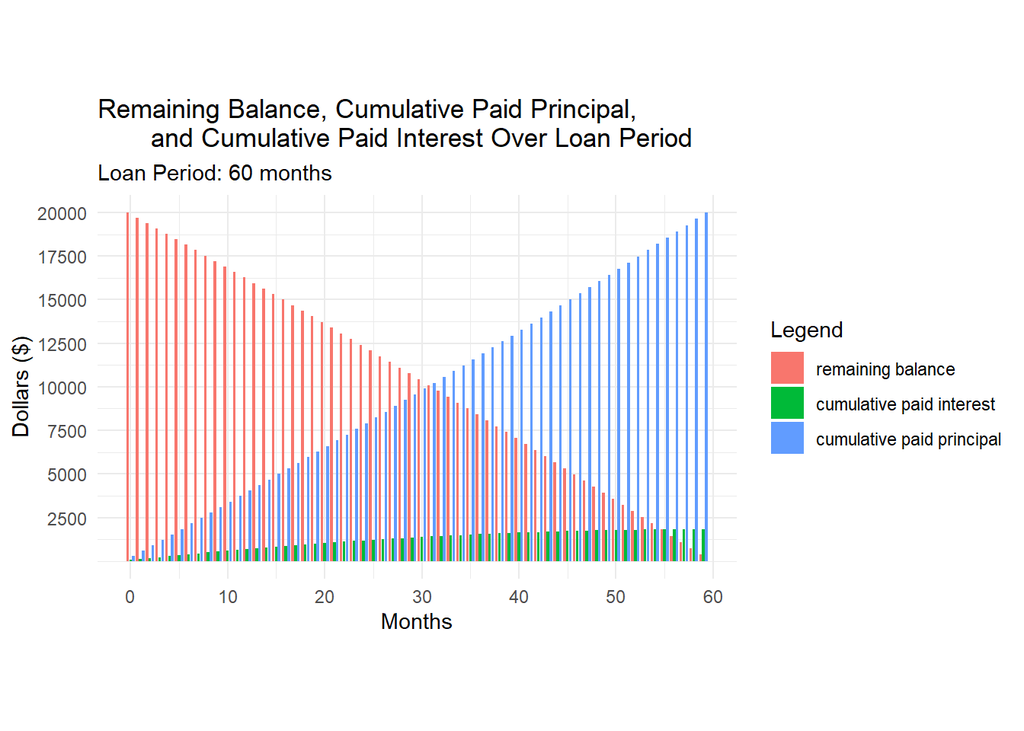

```r
amortization_table_long <- melt(amortization_table, id="term")

ggplot(amortization_table_long %>% filter(variable == "balance" |
                                          variable == "paid_cum_interest" |
                                          variable == "paid_cum_principal"),
       aes(x = , y = value, fill = variable)) +
  geom_col(aes(x = term), position = "dodge2") +
  scale_fill_discrete(name = "Legend",
                      labels = c("remaining balance",
                             "cumulative paid interest",
                             "cumulative paid principal")) +
  scale_x_continuous(breaks = c(0, 10, 20, 30, 40, 50, 60)) +
  scale_y_continuous(breaks = c(2500, 5000, 7500, 10000,
                                12500, 15000, 17500, 20000)) +
  labs(title = "Remaining Balance, Cumulative Paid Principal,
       and Cumulative Paid Interest Over Loan Period",
       subtitle = "Loan Period: 60 months",
       x = "Months",
       y = "Dollars ($)") +
  theme_minimal() +
  theme(aspect.ratio = 3/5)
```